# Final Project of Workshop 2 with Elena Morotti

Clara Schloesser, Tommaso Aicardi

2023-01-04

## Inroduction

During the course we explored various ways in which the data can be presented. The aim of this work is to exercise some of the different forms of data visualization. For this purpose, we analysed the distribution of Income and Education in Italy, in particular, at regional level.

## Exploratory Data Analysis

As always, the first phase of a Data Analysis is meant to explore the used Data set. Here we want first to understand how our variables work, and how we can manipulate them to make them useful to our project. First we give a look at the Data Frame.

```r
kable(head(df), 'pipe')
```

| df.studio | df.y | df.area3 | df.ireg |
| --- | --- | --- | --- |
| 2 | 17010.000 | 3 | 20 |
| 2 | 11713.000 | 3 | 20 |
| 2 | 20454.979 | 3 | 17 |
| 2 | 9600.000 | 3 | 17 |
| 3 | 9865.201 | 3 | 18 |
| 1 | 4290.000 | 3 | 18 |

```r
nrow(df)
```

```
## [1] 11888
```

The Dataset used is the [Survey of Household of Income and Wealth (SHIW)](https://www.bancaditalia.it/statistiche/tematiche/indagini-famiglie-imprese/bilanci-famiglie/index.html?com.dotmarketing.htmlpage.language=1), in its 2016 version. Each row corresponds to an Italian citizen selected through random techniques. The overall number of observations is 11888. Each column correpsonds to a variable. The selected variables are the following: Educational Attainment (df.STUDIO), Income per Capita(df.Y), Macro Geographical area of living(df.AREA3), Region of living(df.IREG). In the following sections we will better understand the meaning of each variable and its states.

### Education

The first thing that we need for our analysis is Educational Attainment of the Population. It is defined by the last Educational Level accomplished by the individual.

Absolute Frequencies of Educational Attainment in the Dataset

| Educational Attainment | Frequency |
| --- | --- |
| None | 400 |
| Primary | 2495 |
| Lower Secondary | 3324 |
| Vocational Diploma | 966 |
| Upper Secondary Diploma | 3194 |
| 3y Degree | 187 |
| 5y Degree | 1225 |
| Postgraduate | 97 |

Relative Frequencies of Educational Attainment in the Dataset

| Educational Attainment | Frequency |
| --- | --- |
| None | 3.3647376 |
| Primary | 20.9875505 |
| Lower Secondary | 27.9609690 |
| Vocational Diploma | 8.1258412 |
| Upper Secondary Diploma | 26.8674293 |
| 3y Degree | 1.5730148 |
| 5y Degree | 10.3045087 |
| Postgraduate | 0.8159489 |

The first table shows the absolute distribution of Educational Qualification among the population. The modal state is ‘Lower Secondary’, almost tied with ‘Upper Secondary Diploma’. Still, it is difficult to quantify the distances between the different states. The table with relative distributions gives a better quantification of the Level of Education of the population.

For the purpose of the analysis, we will aggregate the observation between people at least graduate, and people at best with a diploma. We will put everything equal or higher than ‘3Y Degree’ it into the same category, and everything lower, into another cateogory.

Graduated VS Not Graduated in Absolute Terms in the Dataset

| Variable | Frequency |
| --- | --- |
| At least Graduated | 1509 |
| Not Graduated | 10379 |

Graduated VS Not Graduated in Relative Terms in the Dataset

| Variable | Frequency |
| --- | --- |
| At least Graduated | 12.69347 |
| Not Graduated | 87.30653 |

This second group of tables instead divides the population between (at least) Graduated and not Graduated. As we can se, only 12.7% of the population achieved at least a 3-years Uiversity Degree.

### Geographical Area

The second variable we will use for our analysis is the geographic area from which the surveyed population comes from. More specifically, the variable divides the population in three parts: North, Centre and South plus Islands. North comprises: Valle D’Aosta, Piemonte, Lombardia, Veneto, Trentino Alto Adige-Sud Tirol, Friuli Venezia Giulia, Liguria ed Emilia Romagna. Center Comprises Toscana, Marche, Umbria and Lazio. South and Islands comprises the rest.

Absolute Frequencies of Geographical Area in the Dataset

| Geografical Area | Frequency |
| --- | --- |
| North | 5210 |
| Centre | 2661 |
| South and Island | 4017 |

Relative Frequencies of Geographical Area in the Dataset

| Geografical Area | Frequency |
| --- | --- |
| North | 43.82571 |
| Centre | 22.38392 |
| South and Island | 33.79038 |

The most populous group comprises the Northern Regions, with almost 44% of the observed individuals coming from there.

### Italian Regions

The third variable we will use for our analysis are the 20 Italian regions from which the surveyed population comes from.

Absolute Frequencies of Italian regions in the Dataset

| Italian regions | Frequency |
| --- | --- |
| Piemonte | 1017 |
| Valle d’Aosta | 51 |
| Lombardia | 1341 |
| Trentino | 364 |
| Veneto | 753 |
| Friuli | 285 |
| Liguria | 417 |
| Emilia Romagna | 982 |
| Toscana | 911 |
| Umbria | 455 |
| Marche | 594 |
| Lazio | 701 |
| Abruzzo | 322 |
| Molise | 179 |
| Campania | 1007 |
| Puglia | 679 |
| Basilicata | 203 |
| Calabria | 282 |
| Sicilia | 852 |
| Sardegna | 493 |

Relative Frequencies of Italian regions in the Dataset

| Italian regions | Frequency |
| --- | --- |
| Piemonte | 8.554845 |
| Valle d’Aosta | 0.429004 |
| Lombardia | 11.280283 |
| Trentino | 3.061911 |
| Veneto | 6.334118 |
| Friuli | 2.397375 |
| Liguria | 3.507739 |
| Emilia Romagna | 8.260431 |
| Toscana | 7.663190 |
| Umbria | 3.827389 |
| Marche | 4.996635 |
| Lazio | 5.896703 |
| Abruzzo | 2.708614 |
| Molise | 1.505720 |
| Campania | 8.470727 |
| Puglia | 5.711642 |
| Basilicata | 1.707604 |
| Calabria | 2.372140 |
| Sicilia | 7.166891 |
| Sardegna | 4.147039 |

The most represented Region is Lombardia with 11.3% of individuals, followed by Piemonte (8.55%) and Campania (8.47%).

### Net Disposable Income Per Capita

The Third Variable of this Dataset is Net Disposable Income. It is the total income available after that all the transfers (taxes, deductions, etc) have been taken into account. It is the total amount of money that a person can effectively spend.

First we are going to check whether there are any missing values.

```r
anyNA(df$df.y)
```

```
## [1] FALSE
```

Everything looks fine from that point of view.

Then we are going to have a further look to the data.

```r
describe(df$df.y)
```

```
## df$df.y
##        n  missing distinct     Info     Mean      Gmd      .05      .10
##    11888        0     7171        1    19030    13289     3600     5850
##      .25      .50      .75      .90      .95
##    10750    16900    23902    32288    40673
##
## lowest :  -6763.192  -4321.011  -3918.000  -2530.282  -2000.000
## highest: 218945.109 229472.922 273079.000 277609.969 541879.188
```

As we can see from the ‘describe’ function, there are some negative values. Given that it is impossible to have a negative Net Disposable Income, we have to further investigate to clear the problem.

```r
table(df$df.y<0)
```

```
##
## FALSE  TRUE
## 11874    14
```

There are 14 Values lower than 0 (The TRUE ones), out of 11888. We chose to recode the negative observations into positive.

```r
df$df.y <- ifelse(df$df.y<=0, df$df.y*-1, df$df.y)

table(df$df.y<0)
```

```
##
## FALSE
## 11888
```

Now that we are done with the resetting of the negative values, we can give a proper look to the data.

| Variable | Mean | Sd | Min | Pctile[25] | Median | Pctile[75] | Max |
| --- | --- | --- | --- | --- | --- | --- | --- |
| Income | 19035.3 | 15165.368 | 0 | 10750 | 16900 | 23901.539 | 541879.188 |

As expected with income data the mean and the median are quite far apart, ss the mean is heavenly influenced by the extreme rich in the sample. For this reason, we are going to concentrate on the median for our further analysis.

## Block 1 - Geographical distribution of Educational Attainment

In the first section we look from different perspectives at the geographical distribution of Educational Attainment in Italy.

The first plot is an Histogram grouping by Macro Geographical Area the level of Education

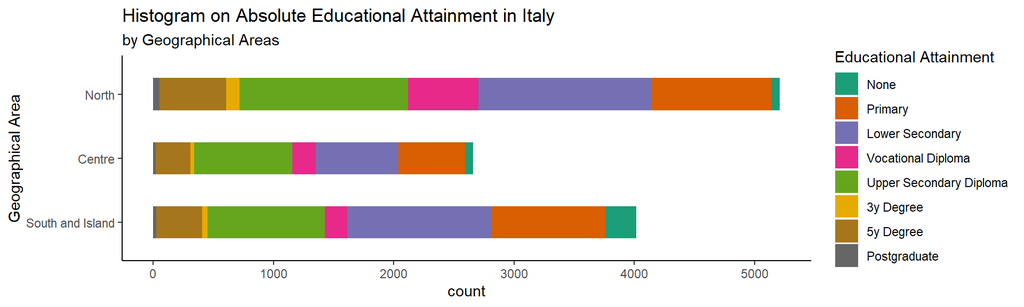

The following graph shows educational attainment not adjusted for population, **i.e. in absolute terms**. We can see that the North has the higher number of observations per each level but ‘None’, which is more present in South and Island. Still, given the nature of this graph, it is hard to make any sort of comparison between the three geographical area, for this reason, the next plot will present the same data but in realtive terms.

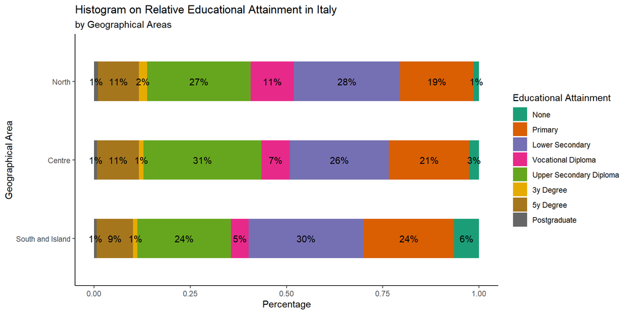

Here the situation appears way more readable. Southern Italy has the higher percentage of people not achieving any kind of diploma, a situation that in Italy is referred with ‘School Dropout’. Centre and North have share similar values in Diploma as maximum attainment, with North having a bigger share of Vocational Diplomas, and Center having a higher share of Upper Secondary Diplomas. North, in general, has the highest level of Vocational Diplomas as maximum attainment, and the highest level of graduates, as we will evalaute in the next chart.

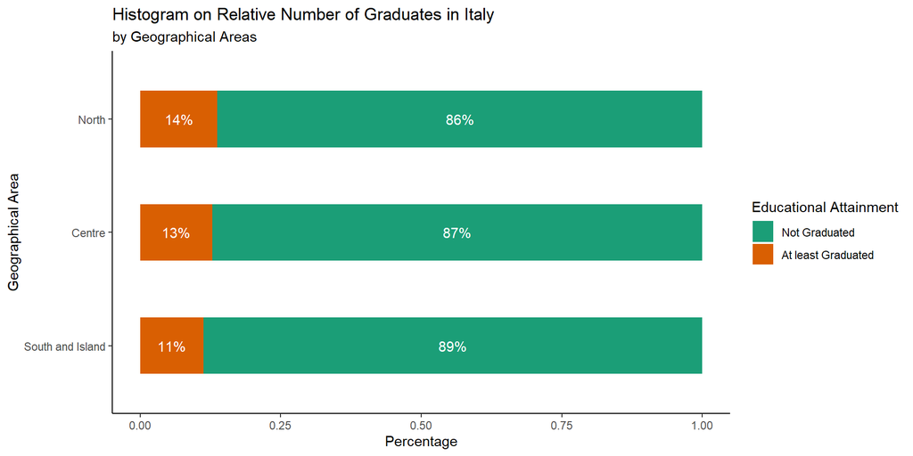

As this chart further highlights, North has the higher number of graduates, followed by Centre and then South. What appears interesting though, is that the differences are really thin, in a order of single percentage points. In overal term, we can see that 12/13% of the italian population is at least graduated.

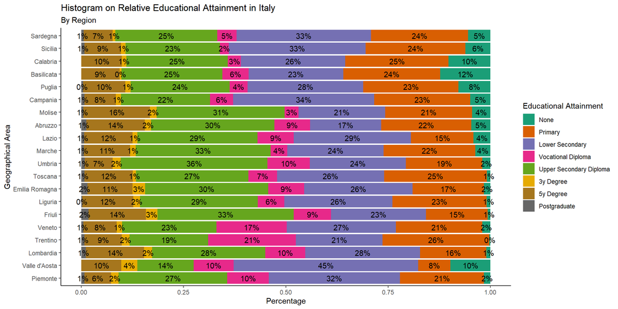

This last graph is in our opinion the most interesting. Looking at Southern Regions first, the presence of tones of blue is quite relevant. Way more than half the population (if we exclude Abruzzo and Molise) has not even obtained a diploma. Moreover, even though Molise and Abruzzo are included in ‘South and Islands’, they perform much more like regions in the Centre-North than those in the South.

Overall, this serie of graphs shows that the population residing in Southern Italy is the one with higher levels of school dropouts. The population living in Central and Northern Italy shares similar Attainments. The overall level of graduates is similar in every Macro Area, but this is biased by the fact that Abruzzi and Molise are considered Southern Regions, and not as Central Regions.

## Block 2 - Income of Graduates

In this second section we will evaluate the distribution of income among graduates, in Italy, and per region. The parameter that we look at is Median Income for Graduates, considering the whole country, and we will compare it with Median Income of the whole population.

```r
median(dfg$Income)
```

```
## [1] 24374.96
```

```r
median (df$df.y)
```

```
## [1] 16900
```

The Median Income of graduates in 2016 is almost 8000 Euros higher than the Median Income, considering the whole population.

Now we look at the differences between regions.

Median income in the diffrent regions of Graduates

| Region | Median Income |
| --- | --- |
| Umbria | 20000.00 |
| Calabria | 20000.00 |
| Trentino | 20089.87 |
| Molise | 20628.00 |
| Veneto | 21273.68 |
| Puglia | 21319.01 |
| Campania | 21711.96 |
| Abruzzo | 21925.33 |
| Sicilia | 22261.27 |
| Marche | 22413.38 |
| Friuli | 23000.00 |
| Basilicata | 23199.87 |
| Emilia Romagna | 24230.62 |
| Valle d’Aosta | 24594.92 |
| Liguria | 25000.00 |
| Toscana | 25835.17 |
| Piemonte | 26000.00 |
| Sardegna | 27000.00 |
| Lazio | 28002.74 |
| Lombardia | 29914.42 |

This table order the Italian Regions from the lowest Median Income of Graduates to the highest. A similar visualization of the same data is the following:

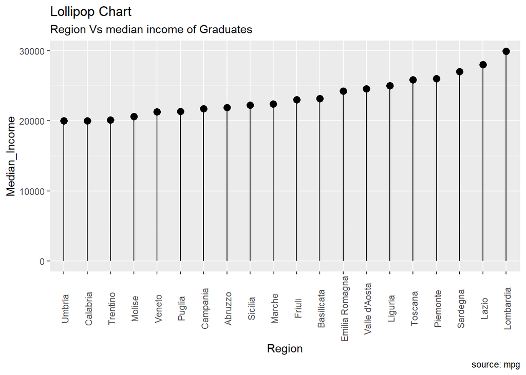

As we can see from the Lollipop Chart, there are some interesting aspects to observe. Regions do not gather together according to their geographical location. We know from facts that in general, Northern Regions are the richest, and that Southern Regions are the poorests, in terms of Income. But, if we look only at Income of Gradutaes in the SHIW, which is a reliable source of Information, we do not see that same trend. Instead, we see that among the three last regions in term of Median income of Graduates, one is Central (Umbria), one is Southern (Calabria), and one is Northern (Trentino Alto Adige). At the same time, if we look at the top, we sese a Northern Region (Lombardia), a Central Region (Lazio), and a Southern Region (Sardegna).

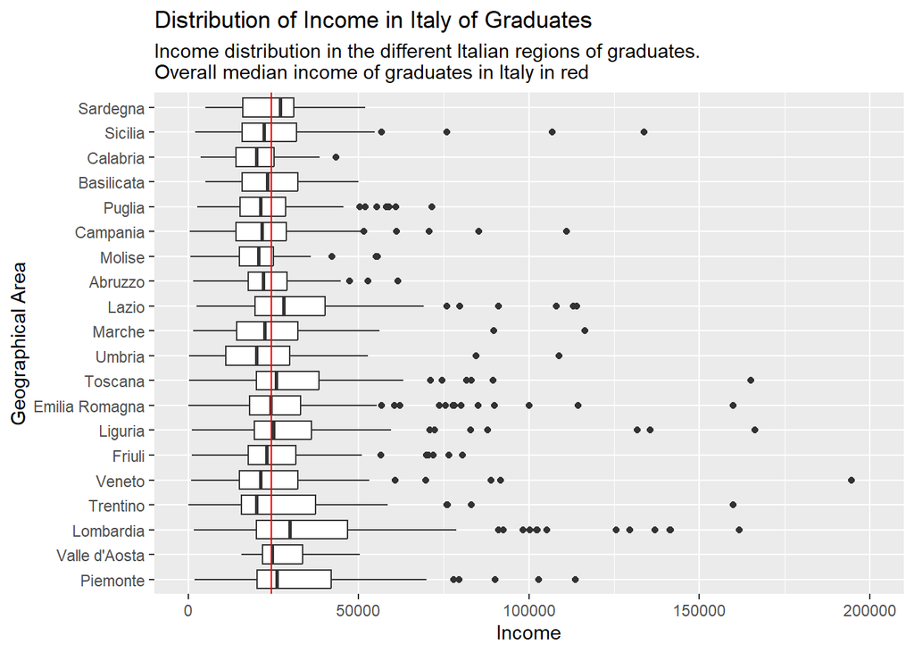

## Block 3 - Maps of Income and Graduates

In the first section we will see a different representation of the data that we already saw before, by using maps.

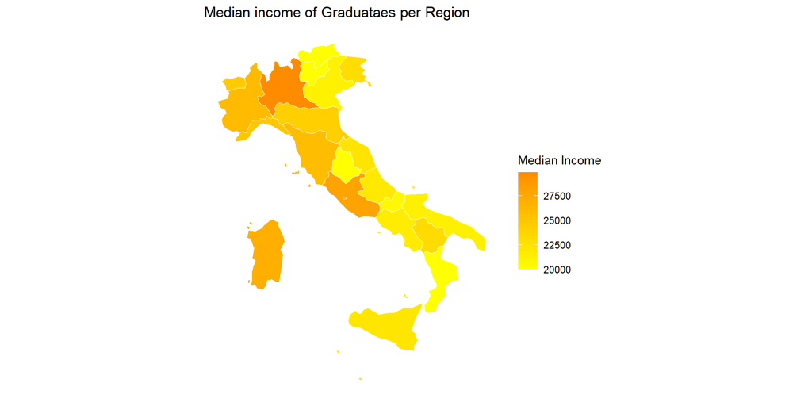

In this first we show the distribution of Median Income of Graduates, per Region. As we can see from the labeling, the gradate scale goes from intense Orange (Highest Income) to intense Yellow (Lowest Income). This map gives an immediate clue of the situation of the country. We can see that in the North Western part of Italy Income is high, as well as Tirrenic Central Italy. At the same time we see that Southern Italy and North East share a low level of income for graduates.

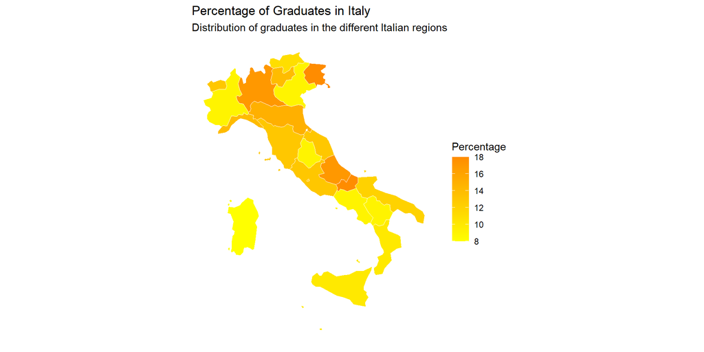

This second map, instead, shows the level of graduates residing in each region. Here we can see that Adriatic Southern Italy (Abruzzo, Molise and Puglia), has got a fair amount of graduates among its residents, if compared to the rest of the South. If we look at Central Italy, the situation is even but for Umbria, as we saw before, which has got one of the lowest level of graduates in Italy. Northern Italy is the most fragmented. While the overall levels of graduates is mid-high, we see that Piemonte and Veneto clearly behave differently.

# Conclusion

The aim of this project was to improve our ability at programming with R. In particular, in this work we learnt to: Code with R MarkDown and Improve our DataViz Capacities. The focus of our analysis was purely descriptive, and we tried to avoid any kind of interpretation or explanation of the data that we presented. Still, we recognize that there is a lot of potential of analysis and research in the work that we have done.